# HW18: Matrix Factorization and Deconvolution

Sophia Frantz

# Introduction and Objective

The dataset I am working with is a simulation of a decomposition experiment. To understand how community composition changes over time, the abundance of microbes from 40 taxa (as measured by 16S transcript counts) was recorded over 100 time points. We would like to know how different communities of associated microbes change in abundance over time. We would also like to know the typical numbers of microbes present in each community. With the current dataset, we only know the abundance of each taxon at each time point. However, we will use nonnegative matrix factorization to doconvolute the current matrix into two matrices.

The solution to the factorization is achieved by findign the maximum likelihood, which equivalent to finding the least squares solution. In other words, this method finds estimates of the two matrices that, when multiplied, give the least squares error when compared to the original matrix.

To find the solutions of the two matrices, I used Stan to implement the model and find the maximum likelihood solution. The model states the the mean values of the given matrix of microbial abundance over time (with dimensions 100 x 40) is the product of two matrices, : *w* = 100 x 3 matrix of the percent of each community at each timepoint, and *x* = 3 x 40 matrix of the abundances of each microbial taxon in each community. We are assuming there are 3 communities, hence the dimensions. The product of these two matrixes represent the mean values of the given matrix, so to represent sample noise, the final values of the given matrix are obtained by drawing from a Poisson distribution with means equal to the product of *x* * *w*. We used the Poission distribution because it describes counts.

The need for matrix factorization to understand communities of microbes and how they change over time is illistrated in the plot below. Each taxon is represented with a differnet color, and the line shows its abundance over time. It is difficult to see just by looking at this data how these different microbes change together or in opposition over time. The matrix factorization will find communities of microbes and the abundance in each community, making it easier to understand the dynamics of this experiment.

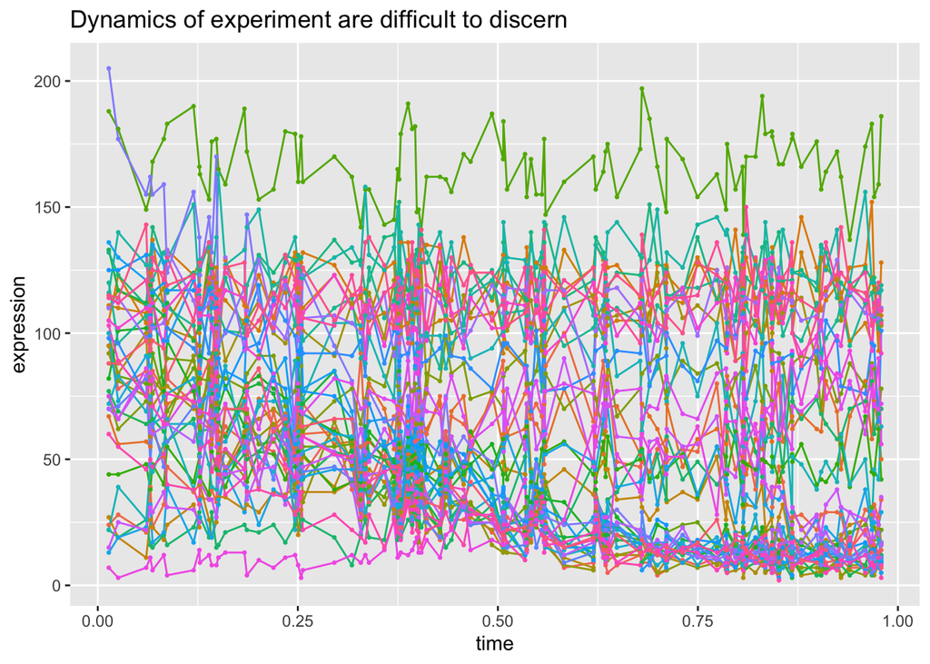

# Further explanation of the model and its priors

We placed priors on the distributions of the values of the matrices to make more informative estimates and avoid non-identifiability (this occurs when there are too many possible solutions and so we are unable to find the most likely solution). The priors are described below:  
- **w:** each row of matrix w must add up to 1, because the 3 values in this row estimate the percent of each community at each timepoint. We used the Dirichlet distribution, which is an extension of the Beta distribution but allows us to draw numbers that add to 1. The shape of the Dirichlet is defined by the parameter $\alpha$, a vector. Larger values in this vector will create a more narrow distribution.  
- $\alpha$ and d$\alpha$: We estimated the parameter of the Dirichlet, $\alpha$, using a normal distribution prior with mean = 0 and SD = 1. We However, we provided more flexibility to estimating the best shape of the Dirichlet distribution by also estimating a scalar to $\alpha$, d$\alpha$. d$\alpha$ was estimated using an exponential distribution prior with rate = 0.2.  
- **x:** Recall that the matrix *x* is the 3 x 40 matrix containing the estimated abundances (mean transcript count) of each taxon in each community. To obtain the values of x, we first estimated the values of *y*, an vector containing the estimates of the mean abundances of each taxon across the 3 communities. The mean for each community then is drawn from a normal distribution with mean y[i] and SD = eta (discussed below). This creates the matrix *x*. We chose to draw from the normal distribution because the values of x are means, and by the property of the Central Limit Theorem, the distribution of means that describe values from any distribution will be normally distributed.  
- $\eta$: The SD of y, $\eta$, was estimated to find an appropriate scale of variation for estimating the average mean abundances of each taxon in each community. $\eta$ has a normal distribution prior with mean = 0 and SD = 10. This was chosen because it gives a wide enough distribution to prevent restricttion of $\eta$.

# Change in community contributions over time

The contribution of Community C in each sample decreases steadily over the course of the experiment. This is in contrast to Community B, which, after a period of sporadic increases and decreases, starts to increase more steadily starting at time 0.40. Overall, Community B then increases for the rest of the experiment, though there are some instances of drastic decreases followed by increases. These opposing patterns suggest that Community B and C may be opposing each other. Similarly, since Community A increases until Community B starts to reliably increase, A and B may also oppose each other or depend on incompatible conditions for growth. Also, interestingly, Community A is highest when thw other two communities are at their lowest. This suggests Community A’s optimal condition is the absence of other communities.

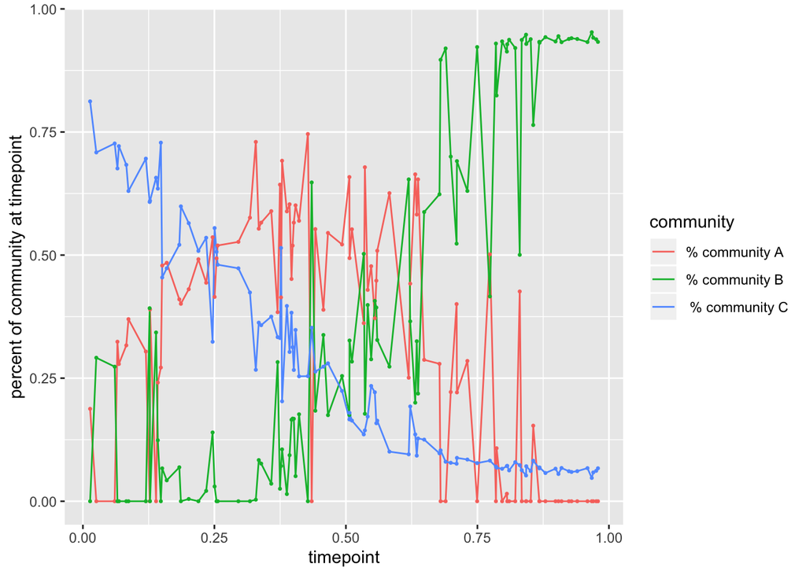

# Taxon composition of communities

The plots below show the relative abundance of each taxa in each community. The actual overall abundance differs by community (community C has almost twice as many counts), so to facilitate comparisons across communities I use the percent abundance of each taxon within each community. The differences in abundance of each taxon across commaunities actually does not seem drastic. I am impressed that the model was able to distinguish between small differences. Of course, the community composition over time changes more drastically between communities, and this may have helped deconvolute the other matrix.

Some noticable trends are that Community C has higher abundance of the “voza” - “wgtt” (pinks) taxa while community B has more of the “osap” - “swfu” (blues and purples) taxa. Community A also has more blue and purple taxa. It also has the most of the orange taxa “deoz” - “fqjw”.

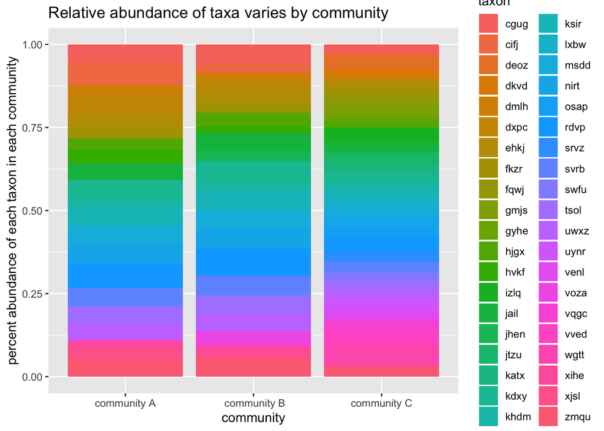